# Развитие стран мира и экономика — анализ данных

### Команда

1. Дейвид Капаца
2. Григорий Макаров

### Введение

Данный отчёт представляет из себя результат работы по анализу данных датасета `GrowthDJ`, который доступен по следующей [ссылке](https://vincentarelbundock.github.io/Rdatasets/articles/data.html).

Сразу же запишем этот датасет в датафрейм `df` и покажем начало таблицы:

```r
df <- read.csv("GrowthDJ.csv")
head(df)
```

```
##   X oil inter oecd gdp60 gdp85 gdpgrowth popgrowth invest school literacy60
## 1 1  no   yes   no  2485  4371       4.8       2.6   24.1    4.5         10
## 2 2  no    no   no  1588  1171       0.8       2.1    5.8    1.8          5
## 3 3  no    no   no  1116  1071       2.2       2.4   10.8    1.8          5
## 4 4  no   yes   no   959  3671       8.6       3.2   28.3    2.9         NA
## 5 5  no    no   no   529   857       2.9       0.9   12.7    0.4          2
## 6 6  no    no   no   755   663       1.2       1.7    5.1    0.4         14
```

#### Кoрoтко о данных

Это данные от 1992 года, в качестве индивидов выступают государства (121), в качестве признаков — различные социоэкономические показатели (10).

1. `oil` factor. Is the country an oil-producing country?
2. `inter` factor. Does the country have better quality data?
3. `oecd` factor. Is the country a member of the OECD? (Организация экономического сотрудничества и развития)
4. `gdp60` Per capita GDP in 1960.
5. `gdp85` Per capita GDP in 1985.
6. `gdpgrowth` Average growth rate of per capita GDP from 1960 to 1985 (in percent).
7. `popgrowth` Average growth rate of working-age population 1960 to 1985 (in percent).
8. `invest` Average ratio of investment (including Government Investment) to GDP from 1960 to 1985 (in percent).
9. `school` Average fraction of working-age population enrolled in secondary school from 1960 to 1985 (in percent).
10. `literacy60` Fraction of the population over 15 years old that is able to read and write in 1960 (in percent).

Так как датасет состоит во многом из экономических данных, наверняка появится желание прологарифмировать некоторые наблюдения, но это потом.

## Первичный анализ данных

### Описательная статистика

```r
summary(df)
```

```
##        X           oil               inter               oecd
##  Min.   :  1   Length:121         Length:121         Length:121
##  1st Qu.: 31   Class :character   Class :character   Class :character
##  Median : 61   Mode  :character   Mode  :character   Mode  :character
##  Mean   : 61
##  3rd Qu.: 91
##  Max.   :121
##
##      gdp60             gdp85         gdpgrowth        popgrowth
##  Min.   :  383.0   Min.   :  412   Min.   :-0.900   Min.   :0.300
##  1st Qu.:  973.2   1st Qu.: 1209   1st Qu.: 2.800   1st Qu.:1.700
##  Median : 1962.0   Median : 3484   Median : 3.900   Median :2.400
##  Mean   : 3681.8   Mean   : 5683   Mean   : 4.094   Mean   :2.279
##  3rd Qu.: 4274.5   3rd Qu.: 7719   3rd Qu.: 5.300   3rd Qu.:2.900
##  Max.   :77881.0   Max.   :25635   Max.   : 9.200   Max.   :6.800
##  NA's   :5         NA's   :13      NA's   :4        NA's   :14
##      invest          school         literacy60
##  Min.   : 4.10   Min.   : 0.400   Min.   :  1.00
##  1st Qu.:12.00   1st Qu.: 2.400   1st Qu.: 15.00
##  Median :17.70   Median : 4.950   Median : 39.00
##  Mean   :18.16   Mean   : 5.526   Mean   : 48.17
##  3rd Qu.:24.10   3rd Qu.: 8.175   3rd Qu.: 83.50
##  Max.   :36.90   Max.   :12.100   Max.   :100.00
##                  NA's   :3        NA's   :18
```

### Виды признаков

Таблица внизу показывает, какую моду имеют наши количественные признаки. Отсюда можно сделать вывод о том, являются они непрерывными или нет.

```r
library(dplyr)
summarize(df, across(gdp60:literacy60, function(x) max(table(x))))
```

```
##   gdp60 gdp85 gdpgrowth popgrowth invest school literacy60
## 1     2     2         5         9      3      4         13
```

1. `oil` качественный
2. `inter` качественный
3. `oecd` качественный
4. `gdp60` количественный почти непрерывный
5. `gdp85` количественный почти непрерывный
6. `gdpgrowth` количественный дискретный
7. `popgrowth` количественный дискретный
8. `invest` количественный дискретный
9. `school` количественный дискретный
10. `literacy60` количественный дискретный

## Matrix plot

Сразу же построим matrix plot для того, чтобы увидеть особенности в наших данных.

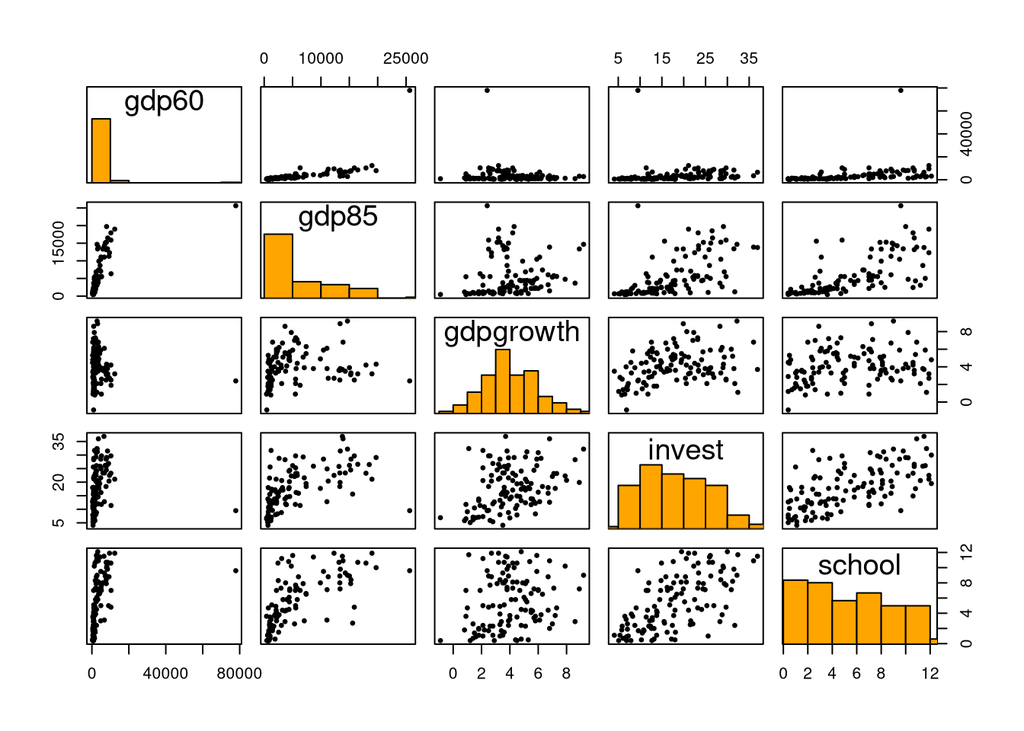

```r
panel.hist <- function(x, ...)
{
    usr <- par("usr"); on.exit(par(usr))
    par(usr = c(usr[1:2], 0, 1.5) )
    h <- hist(x, plot = FALSE)
    breaks <- h$breaks; nB <- length(breaks)
    y <- h$counts; y <- y/max(y)
    rect(breaks[-nB], 0, breaks[-1], y, col = "orange", ...)
}

pairs(~ gdp60 + gdp85 + gdpgrowth + invest + school, data = df, diag.panel = panel.hist, pch = 19,  cex = 0.5)
```

Хорошо видно по гистограммам, что для дальнейшего анализа надо логарифмировать показатели ВВП. Сделаем именно это:

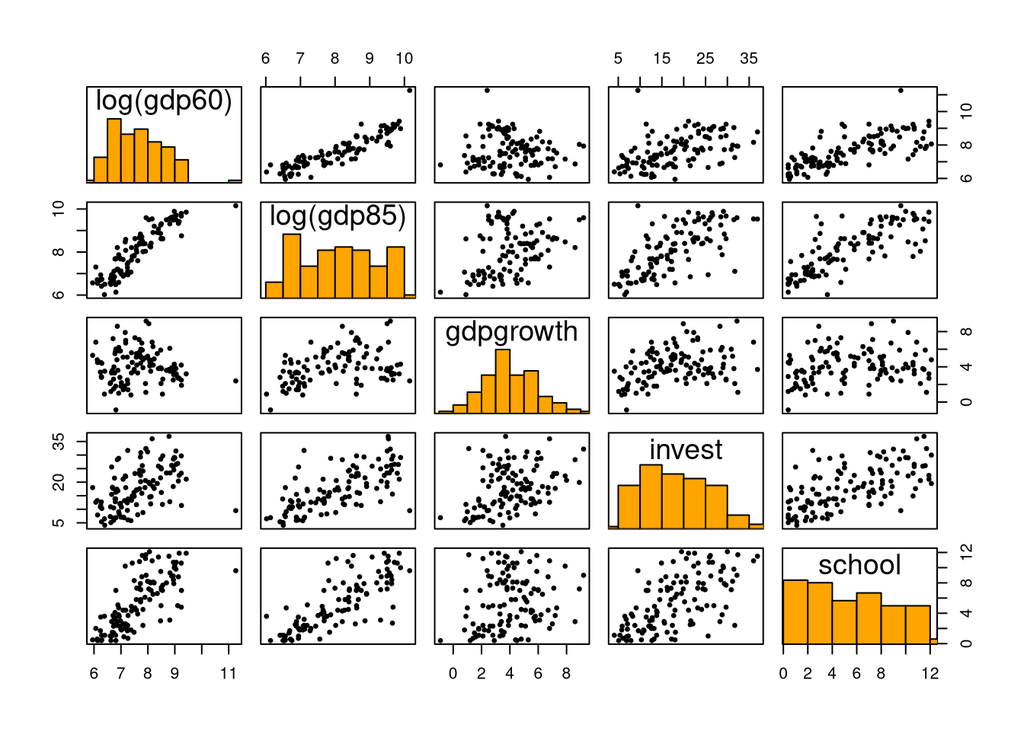

```r
pairs(~ log(gdp60) + log(gdp85) + gdpgrowth + invest + school, data = df, diag.panel = panel.hist, pch = 19,  cex = 0.5)
```

Стало лучше.

### Аутлаеры

Видим очевидный аутлаер по признаку `gdp60`. Его можно заметить и по признаку `gdp60`.

```r
which.max(df$gdp60)
```

```
## [1] 56
```

```r
which.max(df$gdp85)
```

```
## [1] 56
```

Оказывается, что такой высокий показатель ВВП на душу населения наблюдался в Кувейте, одном из крупнейших экспортёров нефти. Уберём его для дальнейшего анализа.

```r
df <- df[-56,]
```

### Неоднородности

#### Нефть

Мы предположили, что страны, которые добывают нефть, должны в целом положительным образом отличаться от других.

[figure not shown]

```r
my_cols <- c("light blue", "orange")
pairs(~ log(gdp60) + log(gdp85) + gdpgrowth + invest + school, data = df, col = my_cols[df$oil], pch = 19,  cex = 0.5, oma=c(3,3,6,8))
par(xpd = TRUE)
legend("bottomright", legend = c("no oil", "oil"), col = my_cols, pch = 19,  cex = 0.5)
title("Matrix Plot (group by oil)")
```

Однако, при делении данных по фактору “нефть”, сложно установить неоднородность данных. Можно предположить, что наличие/отсутствие нефти не влияет на данные экономические показатели.

#### Участие в ОЭСР

ОЭСР — это крупная международная организация, которая была создана для поддержки плана Маршалла для восстановления Западной Европы после Второй Мировой, поэтому ожидаем разницу в соответствующих условных распределениях.

[figure not shown]

```r
pairs(~ log(gdp60) + log(gdp85) + gdpgrowth + invest + school, data = df, col = my_cols[df$oecd], pch = 19,  cex = 0.5, oma=c(3,3,6,10.5))
par(xpd = TRUE)
legend("bottomright", legend = c("non-member", "member"), col = my_cols, pch = 19,  cex = 0.5)
title("Matrix Plot (group by OECD membership)")
```

#### Качество данных

[figure not shown]

```r
pairs(~ log(gdp60) + log(gdp85) + gdpgrowth + invest + school, data = df, col = my_cols[df$inter], pch = 19,  cex = 0.5, oma=c(3,3,6,10))
par(xpd = TRUE)
legend("bottomright", legend = c("poor quality", "good quality"), col = my_cols, pch = 19,  cex = 0.5)
title("Matrix Plot (group by quality of data)")
```

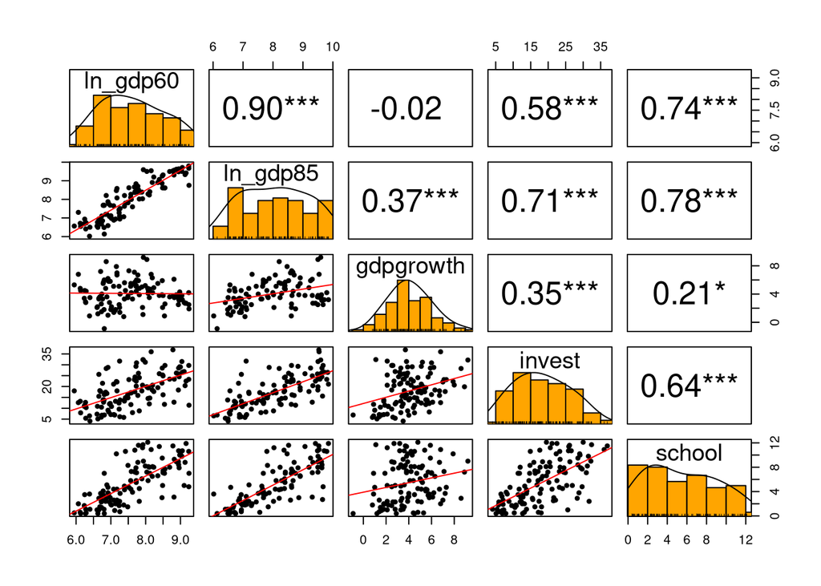

```r
library(psych)
df_for_cor <- data.frame( "ln_gdp60"     = log(df$gdp60),
                          "ln_gdp85"     = log(df$gdp85),
                          "gdpgrowth" = df$gdpgrowth,
                          "invest"    = df$invest,
                          "school"    = df$school)

ind_60 <- which.max(df_for_cor$ln_gdp60)
ind_85 <- which.max(df_for_cor$ln_gdp85)
df_for_cor$ln_gdp60[ind_60] <- NA
df_for_cor$ln_gdp85[ind_85] <- NA

pairs.panels(df_for_cor,
             method = "pearson",
             hist.col = "orange",
             density = TRUE,
             ellipses = FALSE,
             lm = TRUE,
             stars = TRUE
             )
```

1. Между ВВП на душу населения в 1960 и средним отношением инвестиций наблюдается корреляция с коэфицентом 0.58. Между ВВП на душу населения в 1985 и средним отношением инвестиций наблюдается корреляция с коэфицентом 0.71. Чем больше инвестируют в страну, тем больше она производит и тем больше ВВП.
2. Так же показатели ВВП хорошо коррелируют со средней долей населения трудоспособного возраста, посещавшего среднюю школу.

### О виде распределений и о сравнении распределений

**План:**

1. Сравнение распределений: ящики с усами, гистограммы, критерии нормальности *(Григорий Макаров)*
2. Сравнение распределений: сравнение групп, форма распределений, парные критерии *(Дейвид Капаца)*

#### Выбор категоризующей переменной

*Выберите в данных категоризующую переменную. По ней выборка разбивается на подвыборки (например, случай, когда вы увидели неоднородность при первичном анализе, но необязательно).*

После проведённого первичного анализа наблюдалась неоднородность по признаку “Участие в ОЭСР”. Разбивать данные будем по этому признаку.

#### Сравнение распределений: ящики с усами

*Сначала имеет смысл посмотреть на сравнение сравнение распределений в группах с помощью ящиков с усами (box plot). С помощью ящиков с усами там, где групп больше двух, можно выбрать две из них, которые интересно сравнить с помощью критериев.*

Для первичного сравнения распределений посмотрим на ящики с усами, которые дадут первоначальное представление о разнице в распределениях по категоризующей переменной.

##### Изменение ВВП

Построим box плоты для значений ВВП на душу населения в 1960 и 1985 годах, с категоризацией по членству в ОЭСР. Предполагаем, что членство в ОЭСР способствует более согласованному росту ВВП среди стран-участниц за счёт совместных договорённостей и взаимопомощи уже достаточно развитых государств.

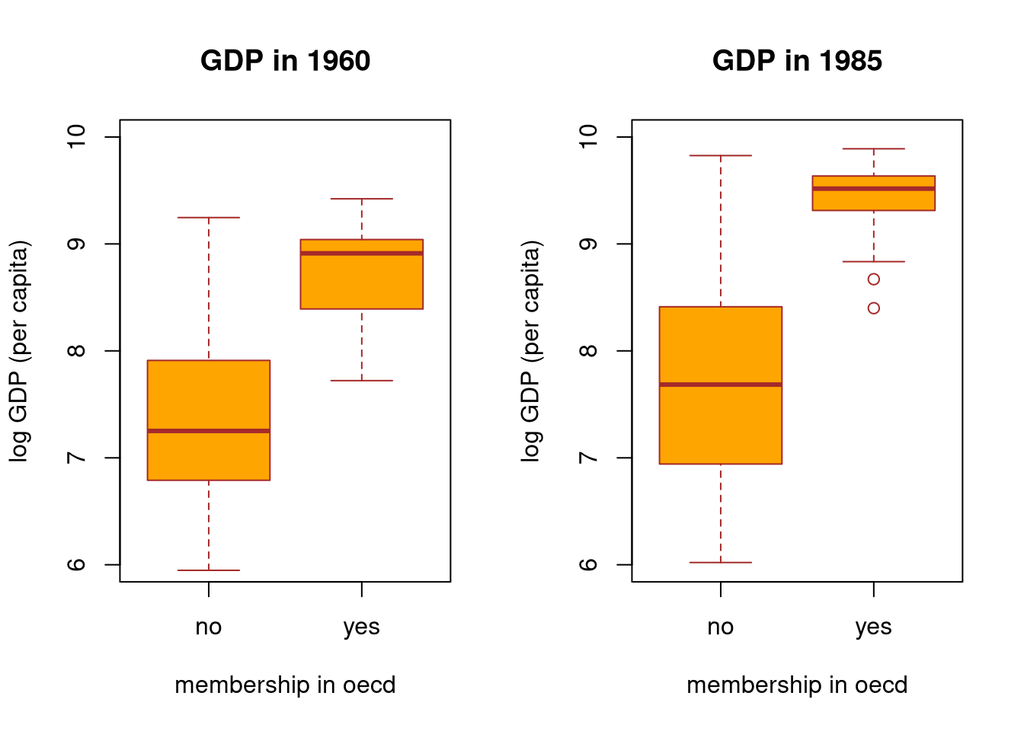

Из ящиков с усами действительно видим, что членство в организации действительно приводит к уменьшению межквартильного размаха и предположительному росту ВВП в среднем.

В свою очередь у оставшихся стран на первый взгляд такой сходимости не наблюдается.

##### Образование

Так как нам заведомо известно, что страны ОЭСР достаточно развитые, можем ожидать в среднем более высокую долю обучающихся в средней школе, а также меньший разброс.

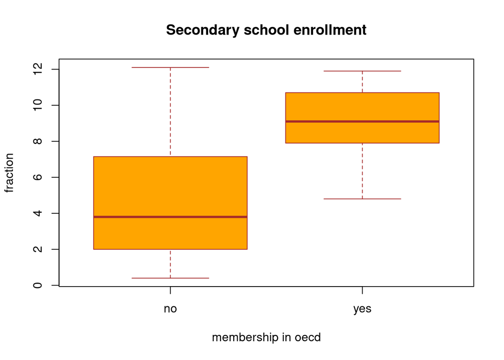

Наши предположения в целом подтверждаются графиком сверху.

Так что на первый взгляд можно предположить, что наблюдаются отличия во всех сравнениях.

#### Нормальность признаков: визуально и критерии

*Проверьте, близко ли распределение выбранных признаков к нормальному. Можно использовать различные критерии для проверки этой гипотезы, можно рисовать normal probability plot.*

Построим гистограммы и qqplotы распределений по группам:

##### Нормальность ВВП: визуально

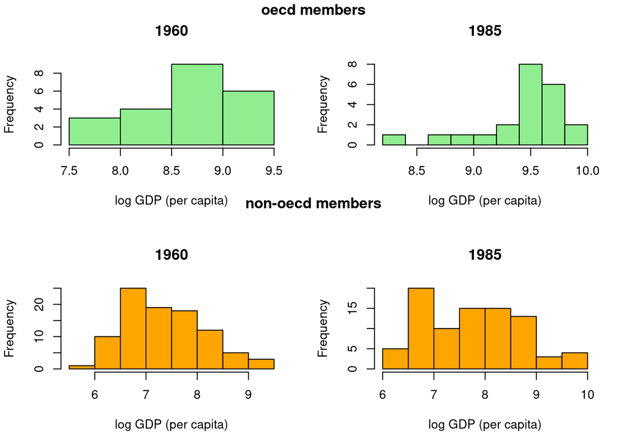

Членов ОЭСР достаточно мало (22), поэтому гистограмма для них выглядит не очень убедительно. Видим для не членов некоторую симметричность, насчёт нормальности уверенности нет.

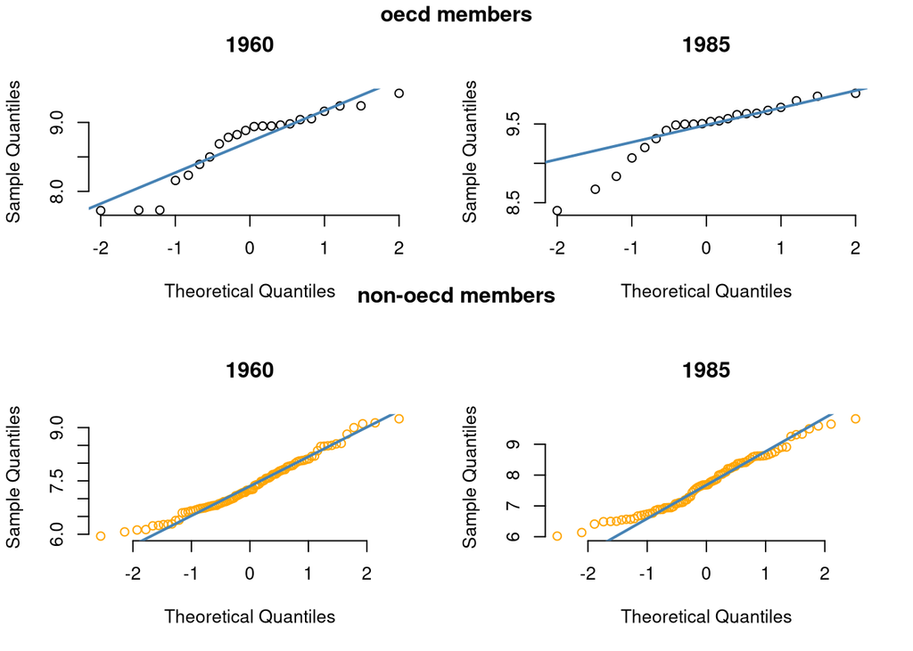

Построив Normal Probability Plot, видим аналогичные результаты.

Теперь воспользуемся критериями для проверки распределений на нормальность.

##### Нормальность ВВП + Инвестиции + Образование: критерии

*Критерий Шапиро-Уилка*

```
##
##  Shapiro-Wilk normality test
##
## data:  log(df$gdp60[df$oecd == "yes"])
## W = 0.88487, p-value = 0.01498
```

```
##
##  Shapiro-Wilk normality test
##
## data:  log(df$gdp60[df$oecd == "no"])
## W = 0.97501, p-value = 0.07117
```

```
##
##  Shapiro-Wilk normality test
##
## data:  log(df$gdp85[df$oecd == "yes"])
## W = 0.8597, p-value = 0.005064
```

```
##
##  Shapiro-Wilk normality test
##
## data:  log(df$gdp85[df$oecd == "no"])
## W = 0.96819, p-value = 0.03387
```

```
##
##  Shapiro-Wilk normality test
##
## data:  df$invest[df$oecd == "yes"]
## W = 0.95934, p-value = 0.476
```

```
##
##  Shapiro-Wilk normality test
##
## data:  df$invest[df$oecd == "no"]
## W = 0.96148, p-value = 0.005757
```

```
##
##  Shapiro-Wilk normality test
##
## data:  df$school[df$oecd == "yes"]
## W = 0.94489, p-value = 0.2493
```

```
##
##  Shapiro-Wilk normality test
##
## data:  df$school[df$oecd == "no"]
## W = 0.92982, p-value = 7.473e-05
```

*Критерий согласия Пирсона (Хи-квадрат)*

```
##
##  Pearson chi-square normality test
##
## data:  log(df$gdp60[df$oecd == "yes"])
## P = 9.8182, p-value = 0.0436
```

```
##
##  Pearson chi-square normality test
##
## data:  log(df$gdp60[df$oecd == "no"])
## P = 13.656, p-value = 0.1893
```

```
##
##  Pearson chi-square normality test
##
## data:  log(df$gdp85[df$oecd == "yes"])
## P = 13.636, p-value = 0.008551
```

```
##
##  Pearson chi-square normality test
##
## data:  log(df$gdp85[df$oecd == "no"])
## P = 21.871, p-value = 0.009298
```

```
##
##  Pearson chi-square normality test
##
## data:  df$invest[df$oecd == "yes"]
## P = 2.8182, p-value = 0.5887
```

```
##
##  Pearson chi-square normality test
##
## data:  df$invest[df$oecd == "no"]
## P = 11.571, p-value = 0.3148
```

```
##
##  Pearson chi-square normality test
##
## data:  df$school[df$oecd == "yes"]
## P = 0.90909, p-value = 0.9233
```

```
##
##  Pearson chi-square normality test
##
## data:  df$school[df$oecd == "no"]
## P = 30.484, p-value = 0.0007135
```

Сгенeрируем таблицу p-value тестов для **группы, входящей в ОЭСР**:

```
##          Data     Sh_W  Pearson
## 1 log(gdp60)) 0.014980 0.043600
## 2 log(gdp85)) 0.005064 0.008551
## 3      invest 0.476000 0.588700
## 4      school 0.249300 0.923300
```

По полученным результатам можно сделать следующие выводы:

1. Мы отвергаем гипотезу о нормальном распределении следующих признаков: log(gdp60)) и log(gdp85))
2. Нет оснований отвергнуть гипотезу о нормальном распределении признаков: invest и school

Теперь таблица p-value тестов для **группы, не входящей в ОЭСР**:

[output not shown]

#### Сравнение групп: критерии

*Сравните группы между собой. Можно сравнить по разным критериям, например, критерий t-test, который умеет обнаруживать разницу в среднем. Непараметрический аналог, с помощью которого можно обнаруживать сдвиг - критерий Манна-Уитни/Вилкоксона.*

Условием применения t-test считается близость к нормальному распределению, однако при достаточно больших $n$ можем использовать его как асимптотический критерий. Ввиду неплохой симметричности рассмотренных распределений можем считать, что медиана и среднее близки, поэтому будем рассматривать t-test и Mann-Whitney вместе. Известно, что при нормальности данных результаты применения тестов должны совпадать.

**ВВП в 1985 году**

```
##
##  Welch Two Sample t-test
##
## data:  log(gdp85) by oecd
## t = -13.088, df = 84.71, p-value < 2.2e-16
## alternative hypothesis: true difference in means is not equal to 0
## 95 percent confidence interval:
##  -1.939773 -1.428120
## sample estimates:
##  mean in group no mean in group yes
##          7.740158          9.424104
```

```
##
##  Wilcoxon rank sum test with continuity correction
##
## data:  log(gdp85) by oecd
## W = 101, p-value = 1.32e-10
## alternative hypothesis: true location shift is not equal to 0
```

Отвергаем гипотезы о равенстве средних и медиан.

**Инвестиции**

```
##
##  Welch Two Sample t-test
##
## data:  invest by oecd
## t = -7.136, df = 44.316, p-value = 6.956e-09
## alternative hypothesis: true difference in means is not equal to 0
## 95 percent confidence interval:
##  -11.873794  -6.644759
## sample estimates:
##  mean in group no mean in group yes
##          16.53163          25.79091
```

```
##
##  Wilcoxon rank sum test with continuity correction
##
## data:  invest by oecd
## W = 337.5, p-value = 5.191e-07
## alternative hypothesis: true location shift is not equal to 0
```

И здесь отвергаем, как и предполагалось.

**Образование**

```
##
##  Welch Two Sample t-test
##
## data:  school by oecd
## t = -7.9659, df = 48.274, p-value = 2.385e-10
## alternative hypothesis: true difference in means is not equal to 0
## 95 percent confidence interval:
##  -5.544756 -3.310076
## sample estimates:
##  mean in group no mean in group yes
##          4.658947          9.086364
```

```
##
##  Wilcoxon rank sum test with continuity correction
##
## data:  school by oecd
## W = 299, p-value = 1.983e-07
## alternative hypothesis: true location shift is not equal to 0
```

Здесь тоже. В целом можем предположить, что принадлежность к ОЭСР помогает странам развиваться согласованно во многих направлениях.

#### Сравнение групп: форма распределений

*Но распределения могут отличаться не только сдвигом. Рассмотрите критерий Колмогорова-Смирнова, который может обнаружить, если распределения отличаются формой.*

**ВВП в 1985**

Хотелось бы, чтобы отверглось, но КС тест достаточно консервативен, поэтому статистически значимые результаты мы получаем реже, чем предполагается заданным уровнем значимости.

```
##
##  Two-sample Kolmogorov-Smirnov test
##
## data:  log(df$gdp85[df$oecd == "yes"]) and log(df$gdp85[df$oecd == "no"])
## D = 0.81337, p-value = 1.813e-10
## alternative hypothesis: two-sided
```

Всё как и хотелось, отвергаем при любых стандартных уровнях значимости. А если отвергли с КС, “то уж точно” отвергаем.

#### Парные критерии

*Если есть признаки, которые характеризуют одно и то же (например, время, которое человек тратит на сон, и время на работу), то аналогично производится сравнение по t-критерию и по непараметрическим критериям, они называются парными.*

```r
not_na <- !(is.na(df$gdp60) | is.na(df$gdp85))
t.test(log(df$gdp60[not_na]), y = log(df$gdp85[not_na]))
```

```
##
##  Welch Two Sample t-test
##
## data:  log(df$gdp60[not_na]) and log(df$gdp85[not_na])
## t = -3.3689, df = 200.64, p-value = 0.0009047
## alternative hypothesis: true difference in means is not equal to 0
## 95 percent confidence interval:
##  -0.7354402 -0.1923820
## sample estimates:
## mean of x mean of y
##  7.595747  8.059658
```

```r
t.test(log(df$gdp60[not_na]), y = log(df$gdp85[not_na]), paired = TRUE)
```

```
##
##  Paired t-test
##
## data:  log(df$gdp60[not_na]) and log(df$gdp85[not_na])
## t = -10.451, df = 103, p-value < 2.2e-16
## alternative hypothesis: true difference in means is not equal to 0
## 95 percent confidence interval:
##  -0.5519500 -0.3758722
## sample estimates:
## mean of the differences
##              -0.4639111
```

### Aнализ зависимостей и их первичное исследование

**План:**

1. Анализ зависимостей: первичный поиск зависимостей, критерий Пирсона *(Дейвид Капаца)*
2. Анализ зависимостей: критерий Спирмена, сравнительный анализ *(Григорий Макаров)*

*Вспомните, какие бывают виды зависимостей и чем они измеряются, по каким формулам. Посмотрите на основе matrix plot, какие зависимости у вас в данных. Не забудьте, что при неоднородных данных изучать зависимости имеет смысл только внутри групп по-отдельности.*

*Начинать нужно с анализа линейных зависимостей. На основе коэффициента корреляции Пирсона нужно проинтерпретировать значимые зависимости. При наличие в данных пропусков обратите внимание на выбор между casewise and pairwise MD deletion (в чем разница, какие недостатки и достоинства у этих вариантов?).*

*Замечание:* везде используем pairwisе, понимая, что соответствующие полученные распределения немного отличаются друг от друга. Если удалять casewise, то удалим уже много стран, а это повлияет на критерии.

Вернёмся к нашему matrix plot, который факторизует по странам, входящим и не входящим в ОЭСР.

[figure not shown]

```r
pairs(~ log(gdp60) + log(gdp85) + gdpgrowth + invest + school, data = df, col = my_cols[df$oecd], pch = 19,  cex = 0.5, oma=c(3,3,6,10.5))
par(xpd = TRUE)
legend("bottomright", legend = c("non-member", "member"), col = my_cols, pch = 19,  cex = 0.5)
title("Matrix Plot (group by OECD membership)")
```

Посмотрим на график, где отображены корреляции с факторизацией по членству в ОЭСР.

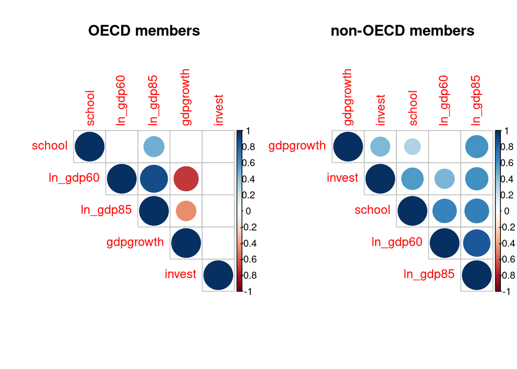

```r
#install.packages("Hmisc")
#install.packages("corrplot")
library(Hmisc)
library(corrplot)
par(mfrow=c(1,2))

df_matrix <- as.matrix(df_for_cor)
df_oecd <- df_matrix[which(df$oecd == "yes"),]
df_noecd <- df_matrix[which(df$oecd == "no"),]
res_oecd <- rcorr(df_oecd)
res_noecd <- rcorr(df_noecd)
corrplot(res_oecd$r, type="upper", order="hclust",
         p.mat = res_oecd$P, sig.level = 0.05, insig = "blank")
title("OECD members")

corrplot(res_noecd$r, type="upper", order="hclust",
         p.mat = res_noecd$P, sig.level = 0.05, insig = "blank")
title("non-OECD members")
```

Здесь достаточно наглядно показаны значимые ($\alpha = 0.05$) корреляции и их величины. Изучим подробнее некоторые зависимости, которые мы предполагали посмотреть ещё в начале исследования.

1. **Влияние инвестиций на рост ВВП**

Предполагаем, что увеличение инвестиций в страну должно положительным образом влиять на рост ВВП, ведь инвестиции помогают *ускорить* производственные и бизнес-процессы. Также предполагаем, что на более развитые страны увеличение инвестиций на рост ВВП действует не так сильно.

```r
cor.test(df$invest[which(df$oecd == "no")], df$gdpgrowth[which(df$oecd == "no")])
```

```
##
##  Pearson's product-moment correlation
##
## data:  df$invest[which(df$oecd == "no")] and df$gdpgrowth[which(df$oecd == "no")]
## t = 4.7075, df = 92, p-value = 8.828e-06
## alternative hypothesis: true correlation is not equal to 0
## 95 percent confidence interval:
##  0.2612981 0.5904921
## sample estimates:
##       cor
## 0.4405888
```

```r
cor.test(df$invest[which(df$oecd == "yes")], df$gdpgrowth[which(df$oecd == "yes")])
```

```
##
##  Pearson's product-moment correlation
##
## data:  df$invest[which(df$oecd == "yes")] and df$gdpgrowth[which(df$oecd == "yes")]
## t = 1.2147, df = 20, p-value = 0.2386
## alternative hypothesis: true correlation is not equal to 0
## 95 percent confidence interval:
##  -0.1792991  0.6156905
## sample estimates:
##       cor
## 0.2621244
```

Действительно, наши предположения в целом оправдываются. В случае, когда страна не принадлежит организации, гипотеза о равенстве корреляции нулю отвергается при всех стандартных уровнях значимости. В том же случае, когда страна является членом ОЭСР, гипотеза не отвергается при всех стандартных уровнях значимости, то есть критерий не обнаружил зависимость.

2. **Влияние образованности населения на ВВП в 1985 году**

Так как переменная `school` отвечает за часть работоспособного населения, которая обучается в школе — она связана с уровнем образованности населения. Логично предполагать, что в странах, где люди более образованны, будут более высокие показатели ВВП. Однако в данном случае кажется сложным сказать, что является следствием чего. Изучаем именно 1985 год, так как данные по образованию у нас усреднённые с 1960 по 1985, чтобы увидеть эффект политики.

```r
cor.test(df$school[which(df$oecd == "no")], df$gdp85[which(df$oecd == "no")])
```

```
##
##  Pearson's product-moment correlation
##
## data:  df$school[which(df$oecd == "no")] and df$gdp85[which(df$oecd == "no")]
## t = 5.6042, df = 81, p-value = 2.8e-07
## alternative hypothesis: true correlation is not equal to 0
## 95 percent confidence interval:
##  0.3531627 0.6681058
## sample estimates:
##       cor
## 0.5285877
```

```r
cor.test(df$school[which(df$oecd == "yes")], df$gdp85[which(df$oecd == "yes")])
```

```
##
##  Pearson's product-moment correlation
##
## data:  df$school[which(df$oecd == "yes")] and df$gdp85[which(df$oecd == "yes")]
## t = 2.2874, df = 20, p-value = 0.0332
## alternative hypothesis: true correlation is not equal to 0
## 95 percent confidence interval:
##  0.04179198 0.73573159
## sample estimates:
##       cor
## 0.4553768
```

можно предложить такое объяснение. Эффект более заметен на развивающихся странах, так как именно в это время многие из них стали вкладывать свои ресурсы в образование, а у развитых стран уровень образования в целом уже “сошёлся” к какому-то определённому высокому уровню.

Так как образование тоже можно рассматривать как некоторую “инвестицию”, можно предполагать зависимость, связывающую образованность и рост ВВП, **но только в случае, когда страны находятся в стадии своего развития**.

```r
cor.test(df$school[which(df$oecd == "no")], df$gdpgrowth[which(df$oecd == "no")])
```

```
##
##  Pearson's product-moment correlation
##
## data:  df$school[which(df$oecd == "no")] and df$gdpgrowth[which(df$oecd == "no")]
## t = 3.0173, df = 90, p-value = 0.003316
## alternative hypothesis: true correlation is not equal to 0
## 95 percent confidence interval:
##  0.1047771 0.4782205
## sample estimates:
##       cor
## 0.3030901
```

```r
cor.test(df$school[which(df$oecd == "yes")], df$gdpgrowth[which(df$oecd == "yes")])
```

```
##
##  Pearson's product-moment correlation
##
## data:  df$school[which(df$oecd == "yes")] and df$gdpgrowth[which(df$oecd == "yes")]
## t = -0.24945, df = 20, p-value = 0.8056
## alternative hypothesis: true correlation is not equal to 0
## 95 percent confidence interval:
##  -0.4663503  0.3747150
## sample estimates:
##         cor
## -0.05569177
```

В принципе, данные результаты подтверждают наши догадки. Для “развивающихся” стран гипотеза отвергается при всех стандартных уровнях значимости. В случае с со странами ОЭСР критерий не нашёл значимого отклонения от гипотезы при всех стандартных уровнях значимости.

3. **Зависимость ВВП в 1960 году и ВВП в 1985 году**

Здесь делаем тривиальное предположение о том, что показатели ВВП в 1960 году положительным образом связаны с соответствующими показателями в 1985 году, причём от класса стран это зависеть не должно. Это можно интерпретировать примерно так: время было в целом мирным, богатые страны оставались богатыми, бедные - бедными, баланс сил не изменился.

```r
cor.test(log(df$gdp60[which(df$oecd == "no")]), log(df$gdp85[which(df$oecd == "no")]))
```

```
##
##  Pearson's product-moment correlation
##
## data:  log(df$gdp60[which(df$oecd == "no")]) and log(df$gdp85[which(df$oecd == "no")])
## t = 14.154, df = 80, p-value < 2.2e-16
## alternative hypothesis: true correlation is not equal to 0
## 95 percent confidence interval:
##  0.7695042 0.8976793
## sample estimates:
##       cor
## 0.8453484
```

```r
cor.test(log(df$gdp60[which(df$oecd == "yes")]), df$gdp85[which(df$oecd == "yes")])
```

```
##
##  Pearson's product-moment correlation
##
## data:  log(df$gdp60[which(df$oecd == "yes")]) and df$gdp85[which(df$oecd == "yes")]
## t = 7.8911, df = 20, p-value = 1.44e-07
## alternative hypothesis: true correlation is not equal to 0
## 95 percent confidence interval:
##  0.7081287 0.9449863
## sample estimates:
##       cor
## 0.8699969
```

Действительно, всё похоже. В обоих случаях видим очень маленькие p-value. Это свидетельствует о том, что гипотеза отвергается при всех стандартных уровнях значимости.

4. **Зависимость ВВП в 1960 году и роста ВВП**

Здесь предполагаемая зависимость похожа на влияние инвестиций на рост ВВП в случае стран ОЭСР: страны *уже* развитые и рост может “сходиться” к нулю. Если же страна менее развита и/или находится в стадии формирования, предполагаем, что рост ВВП вряд ли будет зависеть от ВВП в “начале пути”.

```r
cor.test(log(df$gdp60[which(df$oecd == "no")]), log(df$gdpgrowth[which(df$oecd == "no")]))
```

```
##
##  Pearson's product-moment correlation
##
## data:  log(df$gdp60[which(df$oecd == "no")]) and log(df$gdpgrowth[which(df$oecd == "no")])
## t = 0.45051, df = 90, p-value = 0.6534
## alternative hypothesis: true correlation is not equal to 0
## 95 percent confidence interval:
##  -0.1589266  0.2498251
## sample estimates:
##       cor
## 0.0474349
```

```r
cor.test(log(df$gdp60[which(df$oecd == "yes")]), df$gdpgrowth[which(df$oecd == "yes")])
```

```
##
##  Pearson's product-moment correlation
##
## data:  log(df$gdp60[which(df$oecd == "yes")]) and df$gdpgrowth[which(df$oecd == "yes")]
## t = -4.5324, df = 20, p-value = 0.0002029
## alternative hypothesis: true correlation is not equal to 0
## 95 percent confidence interval:
##  -0.8717948 -0.4146530
## sample estimates:
##        cor
## -0.7118202
```

Результаты согласованы с предположениями. В случае “развивающихся стран”, гипотеза не отвергается при всех стандартных уровнях значимости, то есть зависимость критерием не обнаружена. В случае стран ОЭСР гипотеза о равенстве коэффициента корреляции нулю отвергается, при этом видим, что зависимость отрицательная.

#### Ранговые коэффициенты корреляции

*Затем можно переходить к ранговым коэффициентам корреляции. Расскажите, при каких условиях коэффициенты корреляции Пирсона и Спирмена примерно равны. Приведите примеры, когда один из них больше другого и наоборот. Сравните результаты на ваших данных. Если при сравнении буду найдены заметные различия в результатах, то попробуйте объяснить причину.*

Так как коэффициент корреляции Спирмана является ранговым аналогом коэффициенту Пирсона, то они примерно равны, когда каждая переменая имеет нормальное распределение. В этом случае два коэффициента корреляции связаны следующей формулой: $r = 2\sin(\frac{\pi}{6}\rho)$, где $\rho$ - коэффициент корреляции Спирмена, а $r$ - коэффициента корреляции Пирсона.

Так как коэффициент корреляции Спирмана основан на рангах, а это значит, что он больше устойчив к выбрасам.

1. **Влияние инвестиций на рост ВВП**

```r
cor.test(df$invest[which(df$oecd == "no")], df$gdpgrowth[which(df$oecd == "no")])
```

```
##
##  Pearson's product-moment correlation
##
## data:  df$invest[which(df$oecd == "no")] and df$gdpgrowth[which(df$oecd == "no")]
## t = 4.7075, df = 92, p-value = 8.828e-06
## alternative hypothesis: true correlation is not equal to 0
## 95 percent confidence interval:
##  0.2612981 0.5904921
## sample estimates:
##       cor
## 0.4405888
```

```r
cor.test(df$invest[which(df$oecd == "no")], df$gdpgrowth[which(df$oecd == "no")], method = "spearman")
```

```
##
##  Spearman's rank correlation rho
##
## data:  df$invest[which(df$oecd == "no")] and df$gdpgrowth[which(df$oecd == "no")]
## S = 72566, p-value = 1.261e-06
## alternative hypothesis: true rho is not equal to 0
## sample estimates:
##       rho
## 0.4757366
```

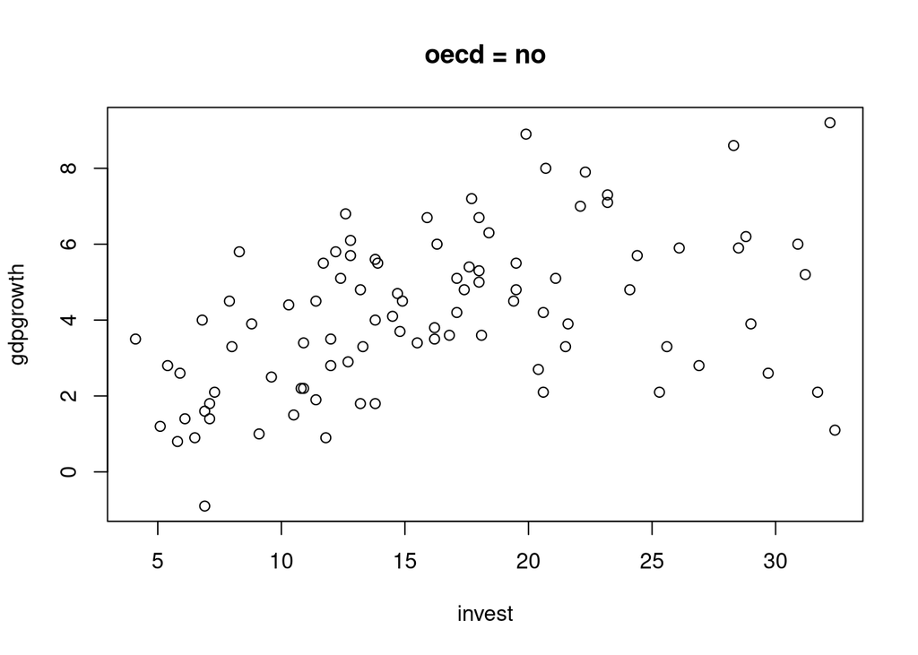

```r
plot(df$invest[which(df$oecd == "no")], df$gdpgrowth[which(df$oecd == "no")], main = "oecd = no", xlab = "invest", ylab = "gdpgrowth")
```

Коэффициенты примерно равно, но Спирман дает более низкий p-value, что скорее всего связано с выбрасами, к которым не устойчив критерий Пирсона.

```r
cor.test(df$invest[which(df$oecd == "yes")], df$gdpgrowth[which(df$oecd == "yes")])
```

```
##
##  Pearson's product-moment correlation
##
## data:  df$invest[which(df$oecd == "yes")] and df$gdpgrowth[which(df$oecd == "yes")]
## t = 1.2147, df = 20, p-value = 0.2386
## alternative hypothesis: true correlation is not equal to 0
## 95 percent confidence interval:
##  -0.1792991  0.6156905
## sample estimates:
##       cor
## 0.2621244
```

```r
cor.test(df$invest[which(df$oecd == "yes")], df$gdpgrowth[which(df$oecd == "yes")], method = "spearman")
```

```
##
##  Spearman's rank correlation rho
##
## data:  df$invest[which(df$oecd == "yes")] and df$gdpgrowth[which(df$oecd == "yes")]
## S = 1599.1, p-value = 0.6673
## alternative hypothesis: true rho is not equal to 0
## sample estimates:
##        rho
## 0.09708473
```

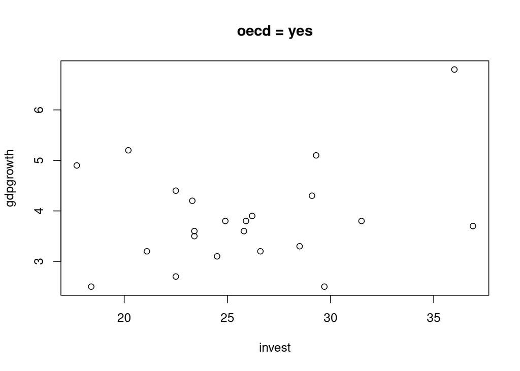

```r
plot(df$invest[which(df$oecd == "yes")], df$gdpgrowth[which(df$oecd == "yes")], main = "oecd = yes", xlab = "invest", ylab = "gdpgrowth")
```

По критерию Спирмена получился более высокий показатель p-value, скорее всего это связано с тем, что коэффициент корреляции Пирсона менее устойчив к выбросам.

2. **Влияние образованности населения на ВВП в 1985 году**

```r
cor.test(df$school[which(df$oecd == "no")], df$gdp85[which(df$oecd == "no")])
```

```
##
##  Pearson's product-moment correlation
##
## data:  df$school[which(df$oecd == "no")] and df$gdp85[which(df$oecd == "no")]
## t = 5.6042, df = 81, p-value = 2.8e-07
## alternative hypothesis: true correlation is not equal to 0
## 95 percent confidence interval:
##  0.3531627 0.6681058
## sample estimates:
##       cor
## 0.5285877
```

```r
cor.test(df$school[which(df$oecd == "no")], df$gdp85[which(df$oecd == "no")], method = "spearman")
```

```
##
##  Spearman's rank correlation rho
##
## data:  df$school[which(df$oecd == "no")] and df$gdp85[which(df$oecd == "no")]
## S = 23834, p-value = 3.428e-16
## alternative hypothesis: true rho is not equal to 0
## sample estimates:
##       rho
## 0.7498662
```

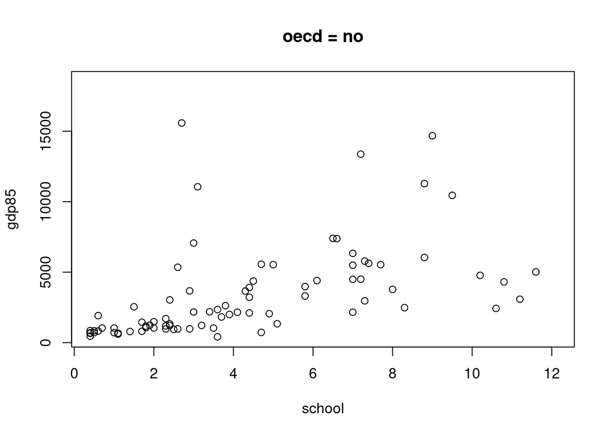

```r
plot(df$school[which(df$oecd == "no")], df$gdp85[which(df$oecd == "no")], main = "oecd = no", xlab = "school", ylab = "gdp85")
```

Так как зависимость монотоная и нелинейная, то p-value критерия Спирмана меньше.

```r
cor.test(df$school[which(df$oecd == "yes")], df$gdp85[which(df$oecd == "yes")])
```

```
##
##  Pearson's product-moment correlation
##
## data:  df$school[which(df$oecd == "yes")] and df$gdp85[which(df$oecd == "yes")]
## t = 2.2874, df = 20, p-value = 0.0332
## alternative hypothesis: true correlation is not equal to 0
## 95 percent confidence interval:
##  0.04179198 0.73573159
## sample estimates:
##       cor
## 0.4553768
```

```r
cor.test(df$school[which(df$oecd == "yes")], df$gdp85[which(df$oecd == "yes")], method = "spearman")
```

```
##
##  Spearman's rank correlation rho
##
## data:  df$school[which(df$oecd == "yes")] and df$gdp85[which(df$oecd == "yes")]
## S = 1206.2, p-value = 0.148
## alternative hypothesis: true rho is not equal to 0
## sample estimates:
##       rho
## 0.3189147
```

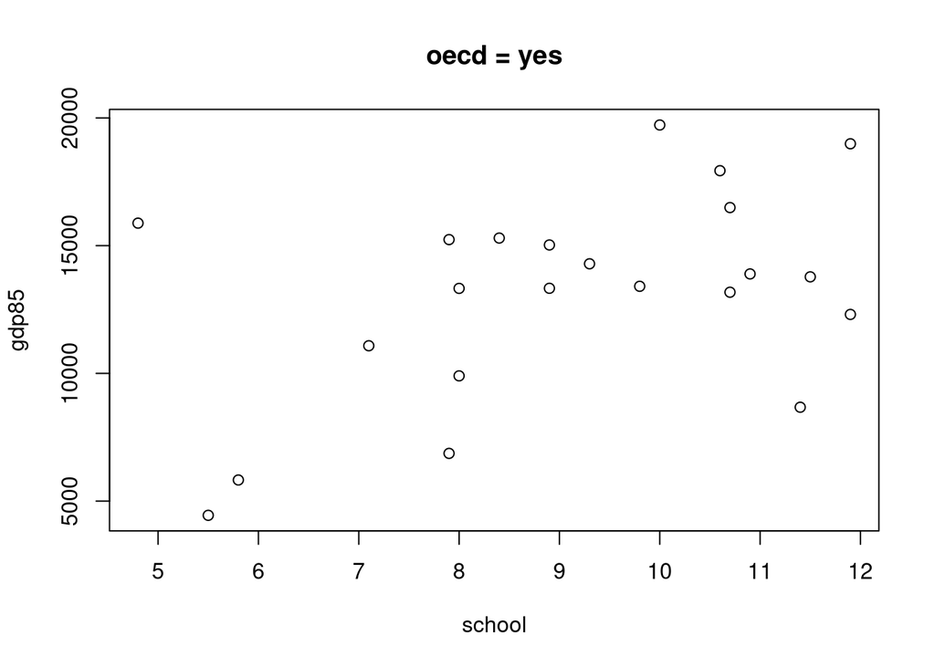

```r
plot(df$school[which(df$oecd == "yes")], df$gdp85[which(df$oecd == "yes")], main = "oecd = yes", xlab = "school", ylab = "gdp85")
```

Из-за наличия выбросов критерий Пирсона дает p-value, которое не дает основания принять нулевую гипотезу. А критерий Спирмана напротив не дает оснований отвергнуть нулевую гипотезу о равенстве коэффициента корреляции 0.

#### Интерпретация найденных корреляций

*Проинтерпретируйте найденные корреляции - можно ли сказать, что является причиной, что следствием. Если есть какая-то другая причина, которая влияет одновременно на оба признака (скрытый фактор), то попробуйте убрать его влияние с помощью частных корреляций.*

#### Частные корреляции

*Влияют ли инвестиции на ВВП за вычетом роста ВВП?*

```r
#install.packages("ppcor")
library(ppcor)
pcor.test(df$gdp85[which(df$oecd == "yes")], df$invest[which(df$oecd == "yes")], df$gdpgrowth[which(df$oecd == "yes")], method = "pearson")
```

```
##   estimate   p.value statistic  n gp  Method
## 1 0.358963 0.1100345  1.676413 22  1 pearson
```

### Линейная регрессия

**План:**

1. Члены ОЭСР *(Дейвид Капаца)*
2. Не члены ОЭСР *(Григорий Макаров)*

**Интересно предсказать ВВП в 1985 году с помощью всех остальных переменных.**

#### Члены ОЭСР

```r
#install.packages("lm.beta")
library(lm.beta)
lm.df.oecd <- lm.beta(lm(data = df[which(df$oecd == "yes"),], log(gdp85) ~ log(gdp60) + gdpgrowth + invest + school))
summary(lm.df.oecd)
```

```
##
## Call:
## lm(formula = log(gdp85) ~ log(gdp60) + gdpgrowth + invest + school,
##     data = df[which(df$oecd == "yes"), ])
##
## Residuals:
##      Min       1Q   Median       3Q      Max
## -0.33917 -0.07664  0.04050  0.09846  0.14480
##
## Coefficients:
##              Estimate Standardized Std. Error t value Pr(>|t|)
## (Intercept)  1.156236     0.000000   1.038221   1.114   0.2809
## log(gdp60)   0.866088     1.159979   0.113424   7.636 6.84e-07 ***
## gdpgrowth    0.142161     0.372381   0.053879   2.639   0.0172 *
## invest       0.009207     0.120922   0.007059   1.304   0.2095
## school      -0.006768    -0.037089   0.019078  -0.355   0.7271
## ---
## Signif. codes:  0 '***' 0.001 '**' 0.01 '*' 0.05 '.' 0.1 ' ' 1
##
## Residual standard error: 0.1465 on 17 degrees of freedom
## Multiple R-squared:  0.8795, Adjusted R-squared:  0.8511
## F-statistic: 31.02 on 4 and 17 DF,  p-value: 1.309e-07
```

##### Описание характеристик

На примере первой модели опишем все полученные характеристики.

`Residuals` : Минимальное, максимальное значение, медиана, и 1, 3 квартили $\mathbf y-\mathbf{\hat y}$, где $\mathbf{\hat y}$ — предсказание по линейной регрессионной модели.

`Coefficients` :

- `Estimate` : оценка коэффициента регрессии у соответствующего признака, можно использовать для предсказания;
- `Standardized` : оценка коэффициента регрессии при стандартизированных признаках, помогает определеить степень влияния признака;
- `Std. Error` : стандартная ошибка для оценки коэффициента
- `t-value` : значение статистики (проверяем гипотезу о равенстве коэффициента регрессии $0$ - аналогично тому, что корреляция между двумя признаками равна $0$);
- `Pr(>|t|)` : p-value для гипотезы;

`Residual standard error` : стандартная ошибка для $\mathbf y-\mathbf{\hat y}$;

`degrees of freedom` : в нашем случае $n - k - 1$, где $n$ - число стран ($22$), $k$ - число параметров ($4$);

`Multiple R-squared` : множественный коэффициент корреляции;

`Adjusted R-squared` : множественный коэффициент корреляции со штрафом за число параметров в модели;

`F-statistic` : статистика к гипотезе о том, что регрессия не значима (строится с использованием $R^2$) с числом параметров, числом степеней свободы, и p-value.

##### Интерпретация результатов, выбор модели

Для членов ОЭСР мы уже показали, что признаки `gdpgrowth` и `log(gdp60)` коррелируют, но удаление `gdpgrowth` из регрессии только ухудшает значимость, поэтому убирать его не будем. `invest` и `school`, в свою очередь, **можно убрать**, так как они не значимы при любых стандартных уровнях значимости.

```r
lm.df.oecd <- lm.beta(lm(data = df[which(df$oecd == "yes"),], log(gdp85) ~ log(gdp60) + gdpgrowth))
summary(lm.df.oecd)
```

```
##
## Call:
## lm(formula = log(gdp85) ~ log(gdp60) + gdpgrowth, data = df[which(df$oecd ==
##     "yes"), ])
##
## Residuals:
##      Min       1Q   Median       3Q      Max
## -0.37486 -0.08823  0.05009  0.09043  0.15599
##
## Coefficients:
##             Estimate Standardized Std. Error t value Pr(>|t|)
## (Intercept)  1.10454      0.00000    0.90864   1.216  0.23903
## log(gdp60)   0.88366      1.18352    0.08894   9.936 5.84e-09 ***
## gdpgrowth    0.16145      0.42290    0.04547   3.550  0.00214 **
## ---
## Signif. codes:  0 '***' 0.001 '**' 0.01 '*' 0.05 '.' 0.1 ' ' 1
##
## Residual standard error: 0.1455 on 19 degrees of freedom
## Multiple R-squared:  0.867,  Adjusted R-squared:  0.853
## F-statistic: 61.94 on 2 and 19 DF,  p-value: 4.743e-09
```

В данном случае p-value уменьшился, а $R^2$ уменьшился совсем немного, поэтому можем выбрать эту модель

##### Анализ остатков

Перейдём к анализу остатков.

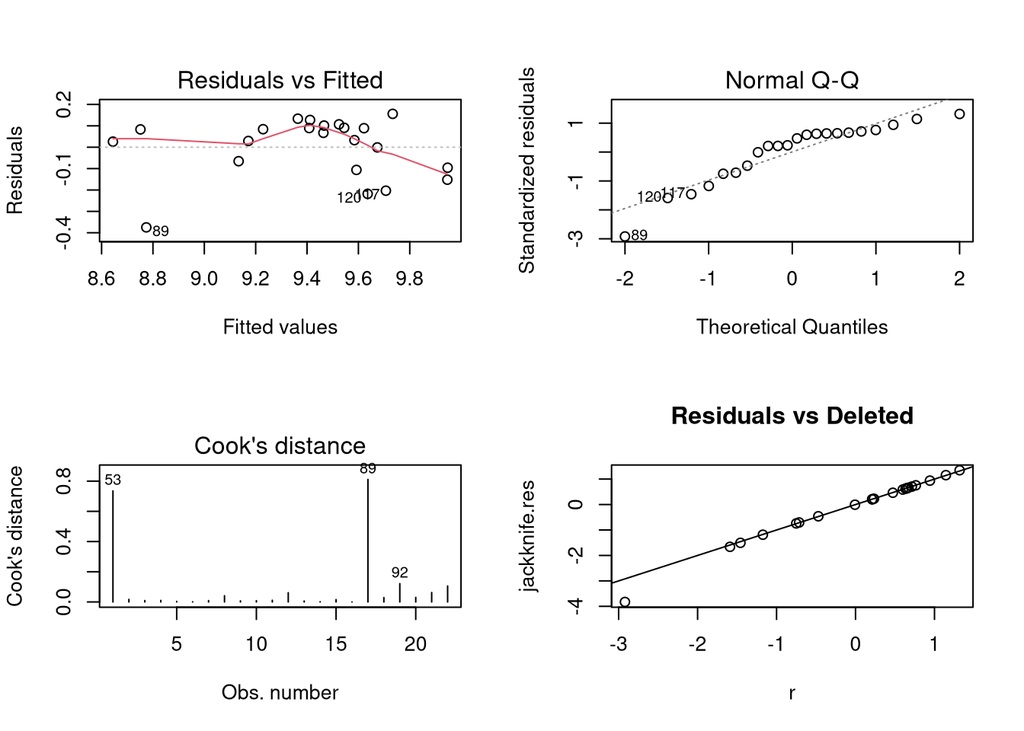

```r
library(MASS) #для deleted residuals
par(mfrow = c(2, 2))
plot(lm.df.oecd, 1)
plot(lm.df.oecd, 2)
plot(lm.df.oecd, 4)
r <- stdres(lm.df.oecd)
jackknife.res <- studres(lm.df.oecd)
plot(jackknife.res ~ r, main = "Residuals vs Deleted")
abline(coef = c(0,1))
```

На первом графике, на котором показаны предсказания $\hat{\mathbf{y}}$ (по оси $x$) и остатки $\mathbf y - \hat{\mathbf{y}}$ (по оси $y$) кажется всё не очень хорошо (видим некоторую нелинейность), но это можно объяснить тем, что у нас маленькая выборка.

С нормальностью остатков по QQ plot всё не совсем хорошо, поэтому к результатам по критериям относимся с осторожностью: они в таком случае асимптотические, а выборка у нас здесь маленькая.

На третьем графике видим, что есть пара кандидатов на аутлаер по распределению (по Куку). Один из критериев для нахождения таких аутлаеров — превышение среднего значения расстояния по Куку в четуре раза. Этому условию соответствуют наблюдения 89 и 53. Если убрать их, у нас станет меньше наблюдений и к тому же появятся новые аутлаеры по Куку .

**Когда остановиться? — я не знаю**

```r
lm.df.oecd <- lm.beta(lm(data = df[which(df$oecd == "yes" & df$X != 89 & df$X != 53),], log(gdp85) ~ log(gdp60) + gdpgrowth))
summary(lm.df.oecd)
```

```
##
## Call:
## lm(formula = log(gdp85) ~ log(gdp60) + gdpgrowth, data = df[which(df$oecd ==
##     "yes" & df$X != 89 & df$X != 53), ])
##
## Residuals:
##      Min       1Q   Median       3Q      Max
## -0.21898 -0.08462  0.02017  0.08601  0.18634
##
## Coefficients:
##             Estimate Standardized Std. Error t value Pr(>|t|)
## (Intercept)  2.22198      0.00000    0.82053   2.708   0.0149 *
## log(gdp60)   0.77131      1.12000    0.07747   9.957 1.65e-08 ***
## gdpgrowth    0.12914      0.28696    0.05062   2.551   0.0207 *
## ---
## Signif. codes:  0 '***' 0.001 '**' 0.01 '*' 0.05 '.' 0.1 ' ' 1
##
## Residual standard error: 0.1119 on 17 degrees of freedom
## Multiple R-squared:  0.8892, Adjusted R-squared:  0.8761
## F-statistic:  68.2 on 2 and 17 DF,  p-value: 7.572e-09
```

Значимость уменьшилась для регрессии в целом и для двух коэффициентов в частности.

Еще раз можем посмотреть на графики по остаткам.

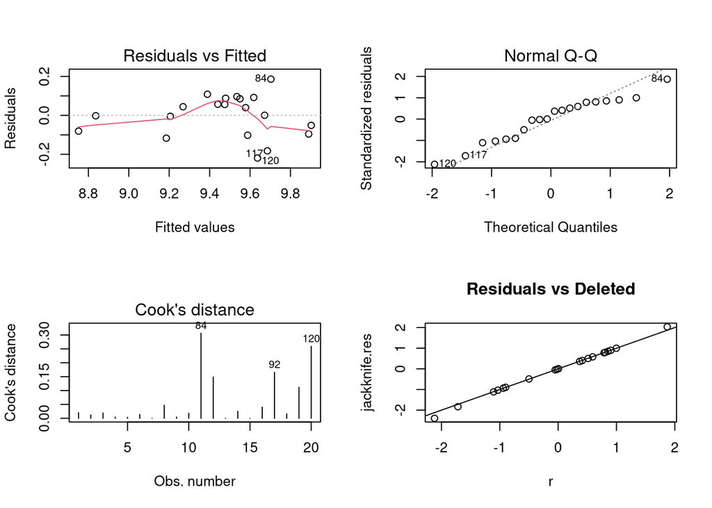

```r
library(MASS) #для deleted residuals
par(mfrow = c(2, 2))
plot(lm.df.oecd, 1)
plot(lm.df.oecd, 2)
plot(lm.df.oecd, 4)
r <- stdres(lm.df.oecd)
jackknife.res <- studres(lm.df.oecd)
plot(jackknife.res ~ r, main = "Residuals vs Deleted")
abline(coef = c(0,1))
```

Первая картинка выглядит чуть более гетероскедастичной, QQ plot практически не поменялся, добавилось несколько новых аутлаеров по Куку, хоть расстояния Кука в целом значительно уменьшились. Лучше стал выглядеть график удалённых остатков.

Я бы оставил предыдущую модель без удаления аутлаеров.

##### AIC: Выбор модели для линейной регрессии

Также выбор модели можно осуществлять на основании информационных критериев, которые базируются на функции максимального правдоподобия для оценок параметров и учитывают число параметров.

Вернёмся к начальной модели (со всеми переменными). “Backward” алгоритм `stepAIC` будет убирать переменные по одной, пока не будет достигнут минимум функции AIC.

```r
lm.df.oecd.full <- lm.beta(lm(data = df[which(df$oecd == "yes"),], log(gdp85) ~ log(gdp60) + gdpgrowth + invest + school))

stepAIC(lm.df.oecd.full, direction = "backward")
```

```
## Start:  AIC=-80.19
## log(gdp85) ~ log(gdp60) + gdpgrowth + invest + school
##
##              Df Sum of Sq     RSS     AIC
## - school      1   0.00270 0.36746 -82.028
## <none>                    0.36476 -80.190
## - invest      1   0.03650 0.40126 -80.092
## - gdpgrowth   1   0.14937 0.51414 -74.639
## - log(gdp60)  1   1.25104 1.61580 -49.447
##
## Step:  AIC=-82.03
## log(gdp85) ~ log(gdp60) + gdpgrowth + invest
##
##              Df Sum of Sq     RSS     AIC
## <none>                    0.36746 -82.028
## - invest      1   0.03504 0.40251 -82.024
## - gdpgrowth   1   0.15582 0.52328 -76.251
## - log(gdp60)  1   1.70264 2.07010 -45.996
```

```
##
## Call:
## lm(formula = log(gdp85) ~ log(gdp60) + gdpgrowth + invest, data = df[which(df$oecd ==
##     "yes"), ])
##
## Coefficients:
## (Intercept)   log(gdp60)    gdpgrowth       invest
##    1.320059     0.843964     0.135187     0.008987
```

В целом, результат работы данного алгоритма не сильно отличается от той модели, которую мы выбрали “вручную”.

##### Попытка предсказания

Попробуем предсказать ВВП для страны, которая имеет средний ВВП и маленький средний ежегодный рост ВВП.

```r
new.country <- data.frame(gdp60 = exp(9), gdpgrowth = 1)

predict.lm(lm.df.oecd, new.country, interval = "confidence")
```

```
##        fit      lwr      upr
## 1 9.292902 9.027324 9.558479
```

```r
predict.lm(lm.df.oecd, new.country, interval = "prediction")
```

```
##        fit      lwr      upr
## 1 9.292902 8.937515 9.648288
```

Изобразим здесь гистограмму, чтобы было понятно, о каких числах и масштабе идёт речь.

Итак, у нас есть предсказание по нашей модели с двумя интервалами:

`confidence`: доверительный интервал для значения ВВП в 1985 году с уровнем $0.95$.

`prediction`: предсказательный интервал.

Приведём примеры ситуаций, когда нам могут понадобиться эти интервалы:

1. Если, например, мы хотим узнать то, какое ВВП имеют страны с похожими характеристиками **в среднем**, то мы смотрим на confidence;
2. Если же мы должны предсказать значение **для конкретной страны** (как для случайной величины), чтобы, например, учитывать это при построении бюджетных планов, то смотрим на prediction. Видно и понятно, что такой интервал существенно шире.

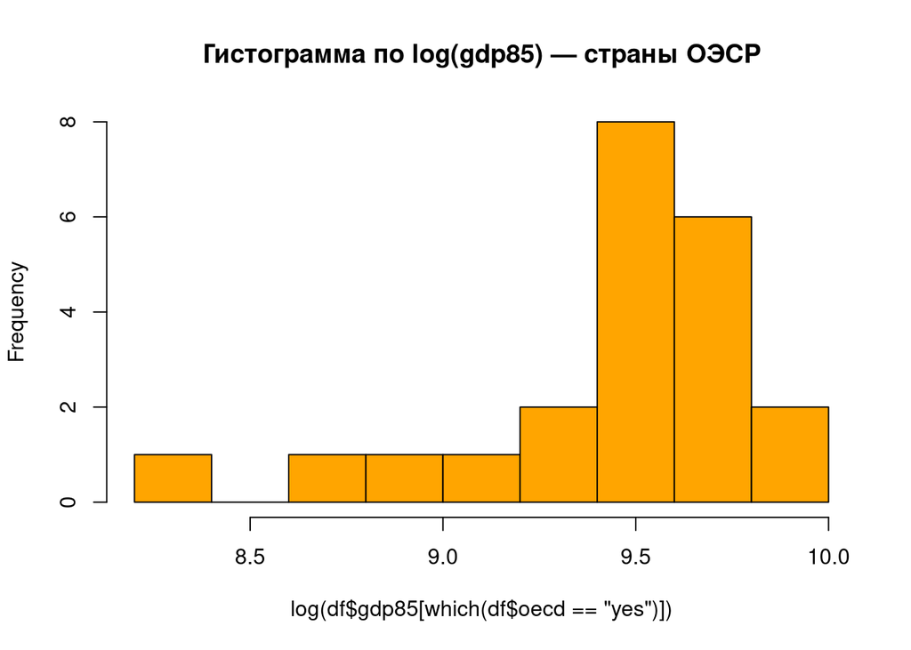

```r
hist(log(df$gdp85[which(df$oecd == "yes")]),col = "orange", main = "Гистограмма по log(gdp85) — страны ОЭСР")
```

#### Не члены ОЭСР

```r
lm.df.noOecd <- lm.beta(lm(data = df[which(df$oecd == "no"),], log(gdp85) ~ log(gdp60) + gdpgrowth + invest + school))
summary(lm.df.noOecd)
```

```
##
## Call:
## lm(formula = log(gdp85) ~ log(gdp60) + gdpgrowth + invest + school,
##     data = df[which(df$oecd == "no"), ])
##
## Residuals:
##      Min       1Q   Median       3Q      Max
## -0.36121 -0.07923 -0.00938  0.08899  0.46113
##
## Coefficients:
##             Estimate Standardized Std. Error t value Pr(>|t|)
## (Intercept) 0.121790     0.000000   0.200048   0.609   0.5445
## log(gdp60)  0.903106     0.763351   0.029404  30.714   <2e-16 ***
## gdpgrowth   0.207540     0.483891   0.009487  21.876   <2e-16 ***
## invest      0.005419     0.042086   0.002986   1.815   0.0735 .
## school      0.009255     0.031332   0.007773   1.191   0.2375
## ---
## Signif. codes:  0 '***' 0.001 '**' 0.01 '*' 0.05 '.' 0.1 ' ' 1
##
## Residual standard error: 0.1425 on 76 degrees of freedom
##   (17 observations deleted due to missingness)
## Multiple R-squared:  0.9753, Adjusted R-squared:  0.974
## F-statistic: 748.8 on 4 and 76 DF,  p-value: < 2.2e-16
```

##### Интерпретация результатов, выбор модели

Коэффициенты при $log(gdp60)$ и $gdpgrowth$ значимы при всех стандартных уровнях значимости.

```r
lm.df.noOecd <- lm.beta(lm(data = df[which(df$oecd == "no"),], log(gdp85) ~ log(gdp60) + invest + school))
summary(lm.df.noOecd)
```

```
##
## Call:
## lm(formula = log(gdp85) ~ log(gdp60) + invest + school, data = df[which(df$oecd ==
##     "no"), ])
##
## Residuals:
##      Min       1Q   Median       3Q      Max
## -1.01585 -0.20957 -0.01949  0.17801  0.94596
##
## Coefficients:
##             Estimate Standardized Std. Error t value Pr(>|t|)
## (Intercept) 1.614767     0.000000   0.504664   3.200  0.00200 **
## log(gdp60)  0.726791     0.614320   0.075890   9.577 9.32e-15 ***
## invest      0.034629     0.268961   0.007168   4.831 6.77e-06 ***
## school      0.057197     0.193638   0.020014   2.858  0.00548 **
## ---
## Signif. codes:  0 '***' 0.001 '**' 0.01 '*' 0.05 '.' 0.1 ' ' 1
##
## Residual standard error: 0.3823 on 77 degrees of freedom
##   (17 observations deleted due to missingness)
## Multiple R-squared:  0.8194, Adjusted R-squared:  0.8124
## F-statistic: 116.5 on 3 and 77 DF,  p-value: < 2.2e-16
```

```r
lm.df.noOecd <- lm.beta(lm(data = df[which(df$oecd == "no"),], log(gdp85) ~ log(gdp60) + gdpgrowth))
summary(lm.df.noOecd)
```

```
##
## Call:
## lm(formula = log(gdp85) ~ log(gdp60) + gdpgrowth, data = df[which(df$oecd ==
##     "no"), ])
##
## Residuals:
##      Min       1Q   Median       3Q      Max
## -0.40664 -0.08230 -0.00450  0.07772  0.45700
##
## Coefficients:
##              Estimate Standardized Std. Error t value Pr(>|t|)
## (Intercept) -0.081243     0.000000   0.160101  -0.507    0.613
## log(gdp60)   0.941159     0.794203   0.021817  43.138   <2e-16 ***
## gdpgrowth    0.219628     0.511363   0.007907  27.775   <2e-16 ***
## ---
## Signif. codes:  0 '***' 0.001 '**' 0.01 '*' 0.05 '.' 0.1 ' ' 1
##
## Residual standard error: 0.1456 on 79 degrees of freedom
##   (16 observations deleted due to missingness)
## Multiple R-squared:  0.9735, Adjusted R-squared:  0.9728
## F-statistic:  1451 on 2 and 79 DF,  p-value: < 2.2e-16
```

##### Анализ остатков

Перейдём к анализу остатков.

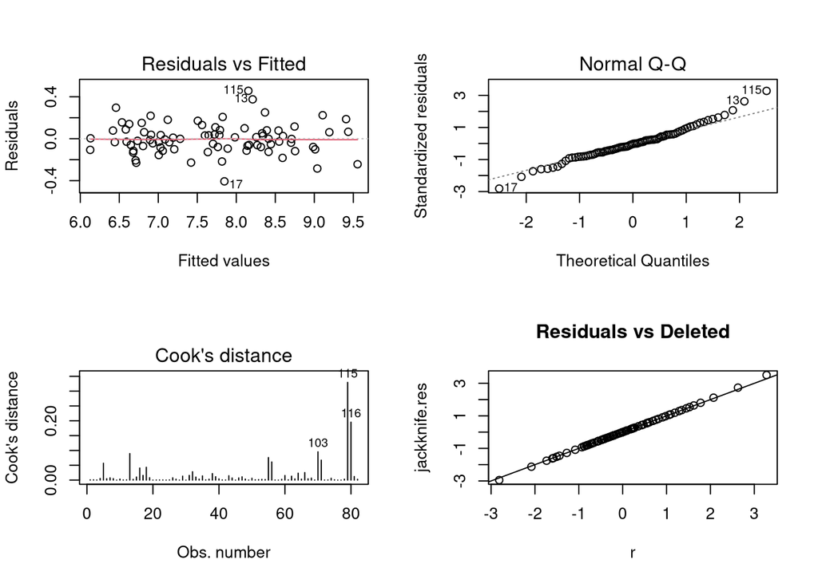

```r
library(MASS) #для deleted residuals
par(mfrow = c(2, 2))
plot(lm.df.noOecd, 1)
plot(lm.df.noOecd, 2)
plot(lm.df.noOecd, 4)
r <- stdres(lm.df.noOecd)
jackknife.res <- studres(lm.df.noOecd)
plot(jackknife.res ~ r, main = "Residuals vs Deleted")
abline(coef = c(0,1))
```

На первом графике, на котором показаны предсказания $\hat{\mathbf{y}}$ (по оси $x$) и остатки $\mathbf y - \hat{\mathbf{y}}$ (по оси $y$). Наши данные распределились относительно симметрично относительно регрессионой прямой, но так же можно заметить несколько выбросов.

С нормальностью остатков по QQ plot можно сказать, что все хорошо, поэтому к результатам по критериям относимся более уверено.

```r
lm.df.noOecd <- lm.beta(lm(data = df[which(df$oecd == "no" & df$X != 19 & df$X != 103 & df$X != 115),], log(gdp85) ~ log(gdp60) + gdpgrowth))
summary(lm.df.noOecd)
```

```
##
## Call:
## lm(formula = log(gdp85) ~ log(gdp60) + gdpgrowth, data = df[which(df$oecd ==
##     "no" & df$X != 19 & df$X != 103 & df$X != 115), ])
##
## Residuals:
##      Min       1Q   Median       3Q      Max
## -0.40212 -0.08171  0.00430  0.07050  0.36759
##
## Coefficients:
##             Estimate Standardized Std. Error t value Pr(>|t|)
## (Intercept) 0.055101     0.000000   0.156804   0.351    0.726
## log(gdp60)  0.917621     0.738654   0.021904  41.893   <2e-16 ***
## gdpgrowth   0.225397     0.525290   0.007566  29.792   <2e-16 ***
## ---
## Signif. codes:  0 '***' 0.001 '**' 0.01 '*' 0.05 '.' 0.1 ' ' 1
##
## Residual standard error: 0.1332 on 76 degrees of freedom
##   (16 observations deleted due to missingness)
## Multiple R-squared:  0.9773, Adjusted R-squared:  0.9767
## F-statistic:  1638 on 2 and 76 DF,  p-value: < 2.2e-16
```

Еще раз можем посмотреть на графики по остаткам.

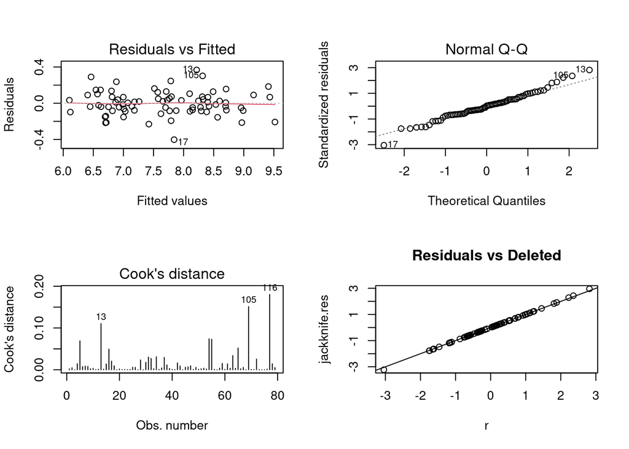

```r
library(MASS) #для deleted residuals
par(mfrow = c(2, 2))
plot(lm.df.noOecd, 1)
plot(lm.df.noOecd, 2)
plot(lm.df.noOecd, 4)
r <- stdres(lm.df.noOecd)
jackknife.res <- studres(lm.df.noOecd)
plot(jackknife.res ~ r, main = "Residuals vs Deleted")
abline(coef = c(0,1))
```

QQ plot практически не поменялся, добавилось несколько новых аутлаеров по Куку, хоть расстояния Кука в целом значительно уменьшились.

Оставим модель без аутлайеров по Куку, так как вырос $R^2$.

##### AIC: Выбор модели для линейной регрессии

```r
#lm.df.noOecd.full <- lm.beta(lm(data = df[which(df$oecd == "no"),], #log(gdp85) ~ log(gdp60) + gdpgrowth + invest + school))

#stepAIC(lm.df.noOecd.full, direction = "backward")
```

### Анализ главных компонент

Теперь проведём анализ главных компонент, все обозначения старались брать из нашего конспекта. Сейчас будем смотреть на все данные сразу, без разбиенния на выявленные неоднородности.

#### Собственные числа

Подключим два пакета и проведём PCA анализ. Параметр `scale.unit` отвечает за нормировку и центрирование, `ncp` задаёт число компонент. Их не может быть больше шести, так как у нас всего рассматривается всего шесть признаков, $p = 6$, а пространство всех главных компонент имеет не большую размерность, чем у исходного пространства.

```r
#install.packages("FactoMineR")
#install.packages("factoextra")
#install.packages("missMDA")
library(FactoMineR)
library(factoextra)
```

```r
library(missMDA)

#CHANGE to log here!
df$gdp60 <- log(df$gdp60)
df$gdp85 <- log(df$gdp85)
imputed.df <-  imputePCA(df[, 5:10], ncp = 3, scale = TRUE) #ncp означает другое: ск-ко комп. исп. для предсказания пропущенных значений
imputed.pca <- PCA(imputed.df$completeObs, ncp = 6, scale.unit = TRUE, graph = FALSE)
```

Для анализа нам не нужно стандартизировать данные, так как это делает функция `PCA()` сама. Центрирование столбцов матрицы плана $\mathbb X$ необходимо для того, чтобы процедура имела статистический смысл. Стандартизация делается для того, чтобы все признаки имели одинаковый масштаб перед анализом, то есть имели одинаковую шкалу (в таком случае говорится об АГК по корреляционной матрице).

Покажем собственные значения матрицы $\frac{1}{n} \mathbb X^\mathrm{T} \mathbb X$.

```r
as.data.frame(imputed.pca$eig)
```

```
##        eigenvalue percentage of variance cumulative percentage of variance
## comp 1 3.46768692             57.7947820                          57.79478
## comp 2 1.37497901             22.9163168                          80.71110
## comp 3 0.61420339             10.2367232                          90.94782
## comp 4 0.28218279              4.7030465                          95.65087
## comp 5 0.24672511              4.1120852                          99.76295
## comp 6 0.01422278              0.2370463                         100.00000
```

`eigenvalue` - это те самые собственные значения, в порядке убывания;

`percentage of variance` для $l$-ого собственного числа можно записать так: $\frac{\lambda_l}{\sum_{i = 1}^{p} \lambda_i} \times 100\%$;

`cumulative percentage of variance` для $l$-ого собственного числа: $\frac{\sum_{i = 1}^{l} \lambda_i}{\sum_{i = 1}^{p} \lambda_i} \times 100\%$.

Переходя к новым признакам $\mathbb Z_i = \mathbb X U_i$, total variance, который равен норме $\|\mathbb X\|^2_{1,2}$, не меняется, и в то же время равен сумме всех собственных значений $\lambda_i$. Этим и объясняeтся variance в названиях столбцов.

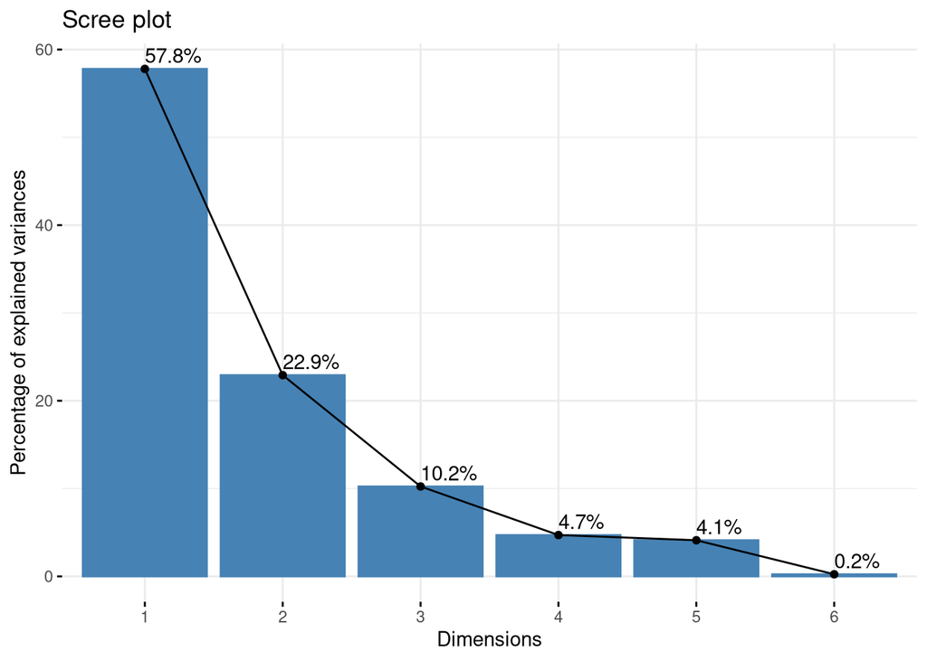

```r
fviz_eig(imputed.pca, addlabels = TRUE)
```

Смотря на scree plot осмысленно выбрать первые три или четыре компоненты.

#### Связь главных компонент со старыми признаками

В этом разделе попробуем интерпретировать полученные результаты через призму связи между старыми и новыми признаками.

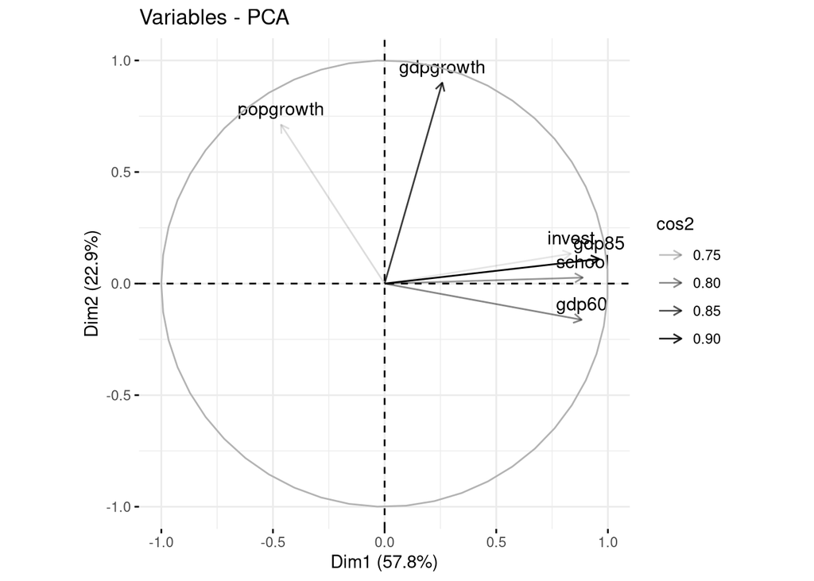

```r
fviz_pca_var(imputed.pca, alpha.var = "cos2")
```

Координаты старых признаков в новом базисе даны в таблице далее (Это $\{f_{ij}\}$):

```r
imputed.pca$var$coord
```

```
##                Dim.1       Dim.2      Dim.3       Dim.4       Dim.5
## gdp60      0.8824333 -0.16231836  0.3901548  0.07290688 -0.17979980
## gdp85      0.9607945  0.11016369  0.1018572 -0.06169788 -0.20776404
## gdpgrowth  0.2580924  0.90027142 -0.2736517 -0.18964287 -0.10317256
## popgrowth -0.4641912  0.71227027  0.4786929  0.20054056  0.08665499
## invest     0.8342775  0.13399382 -0.3492340  0.38976872  0.11018942
## school     0.8875631  0.02690382  0.1600350 -0.21203810  0.37541427
##                   Dim.6
## gdp60      0.0714146106
## gdp85     -0.0859683920
## gdpgrowth  0.0374896863
## popgrowth -0.0180298886
## invest     0.0009866487
## school     0.0008011435
```

В таблице можно увидеть корреляции/косинусы углов между соответствующими признаками; строки соответствуют старым, столбцы — новым признакам. Ясно, что сумма квадратов этих двух элементов даёт длину вектора, которая ограничена единицей (мы проводим анализ по корреляционной матрице, поэтому сумма квадратов всех элементов строки должна быть равна единице как сумма квадратов скалярных произведений по полному базису). Чем ближе стрелка к единичной окружности, тем лучше первые две новых компоненты описывают этот признак.

В нашем случае `gdpgrowth` и `gdp85`

Теперь же посмотрим на собственные векторы $U_i$, так как новые признаки выражаются через старые — $\mathbb Z_i = \mathbb X U_i$, то есть можно посмотреть на столбцы матрицы $U$ и увидеть какая линейная комбинация столбцов $\mathbb X$ привела к новым признакам.

```r
imputed.pca$svd$V
```

```
##            [,1]        [,2]       [,3]       [,4]       [,5]         [,6]
## [1,]  0.4738730 -0.13842662  0.4978297  0.1372471 -0.3619783  0.598817977
## [2,]  0.5159535  0.09394863  0.1299677 -0.1161462 -0.4182767 -0.720852751
## [3,]  0.1385975  0.76775990 -0.3491741 -0.3570025 -0.2077101  0.314354414
## [4,] -0.2492740  0.60743076  0.6108026  0.3775174  0.1744564 -0.151182248
## [5,]  0.4480130  0.11427118 -0.4456157  0.7337392  0.2218366  0.008273138
## [6,]  0.4766277  0.02294383  0.2042015 -0.3991615  0.7557951  0.006717661
```

Как можно видеть, рост населения в первой компоненте имеет отрицательный знак, в то время как остальные характеристики — положительные. Оставшиеся характеристики по смыслу положительны. Поэтому можем интерпретировать первую компоненту как общую характеристику развитости страны. Для второй компоненты сложно дать разумную интерпретацию.

#### Индивиды

Аналогично признакам, отобразим страны на факторной плоскости. Чем темнее точка, тем лучше она описывается первыми двумя компонентами.

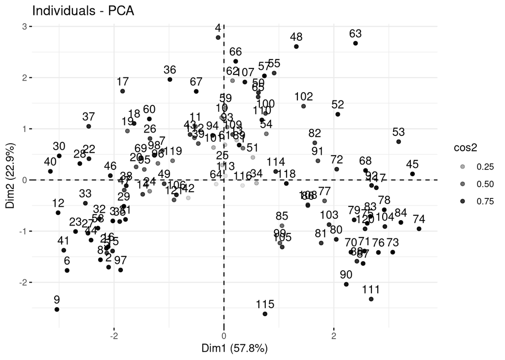

```r
fviz_pca_ind(imputed.pca, alpha.ind = "cos2")
```

Их координаты на этой плоскости можно найти в этой табличке.

```r
head(imputed.pca$ind$coord, 10)
```

```
##         Dim.1      Dim.2      Dim.3       Dim.4       Dim.5         Dim.6
## 1   0.3454069  0.6207020 -0.1077341  0.71367999 -0.20755038  0.0135237095
## 2  -2.0991700 -1.7037673  0.7743895 -0.06993686 -0.26660201 -0.0149974189
## 3  -2.0227208 -0.8004128  0.2267543  0.21482474 -0.04400969 -0.0007999999
## 4  -0.1062223  2.7830112 -1.2898179  0.69070366 -0.28535157  0.0336674630
## 5  -2.1319740 -1.4278004 -1.5734889 -0.31251118 -0.27692163  0.0232495943
## 6  -2.8549328 -1.7678360 -0.1015370 -0.27622198 -0.18901945  0.0021696890
## 7  -1.1215162  0.5743489 -0.6976419 -0.69121602 -0.27891988  0.0133189118
## 8  -2.2479450 -1.5594979 -0.3283602  0.05663807  0.03637118  0.0132941894
## 9  -3.0405185 -2.5302743  0.3867593  0.44835487  0.20208896 -0.0182202174
## 10 -0.0429121  1.2195428 -1.3809644  0.79789135  0.14324635  0.0273473295
```

#### Неоднородности

Для интерпретации возможных неоднородностей, нарисуем biplot

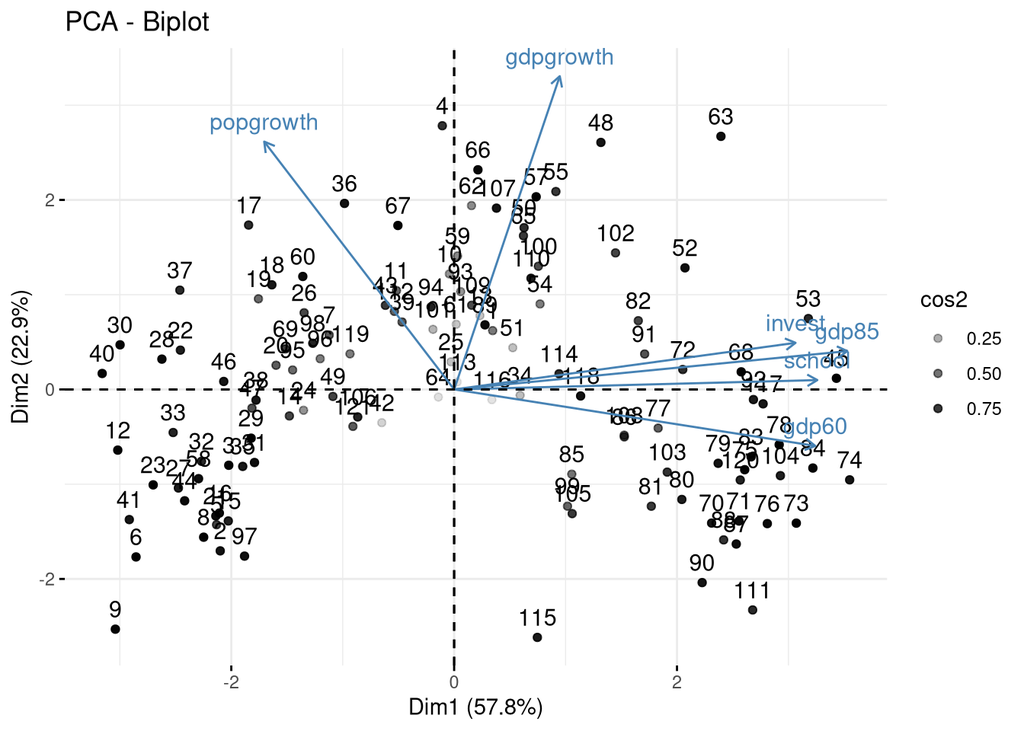

```r
fviz_pca(imputed.pca, alpha.ind = "cos2")
```

Полагаем, что слева на графике мы видим страны “третьего мира”, ближе к центру быстроразвивающиеся, а справа неплохо обособленную группу развитых стран. Сильных выбросов не наблюдается.

Так как большинство развитых стран есть члены ОЭСР, проведём АГК без них и рассмотрим только развивающиеся страны.

##### АГК без неоднородностей

Оставляем только страны, которые не являются членами ОЭСР.

```r
df.noecd <- df[which(df$oecd == "no"), 5:10]
imputed.df.noecd <-  imputePCA(df.noecd, ncp = 3, scale = TRUE) #ncp означает другое: ск-ко комп. исп. для предсказания пропущенных значений
imputed.pca.noecd <- PCA(imputed.df.noecd$completeObs, ncp = 6, scale.unit = TRUE, graph = FALSE)
```

Сразу же приведём biplot.

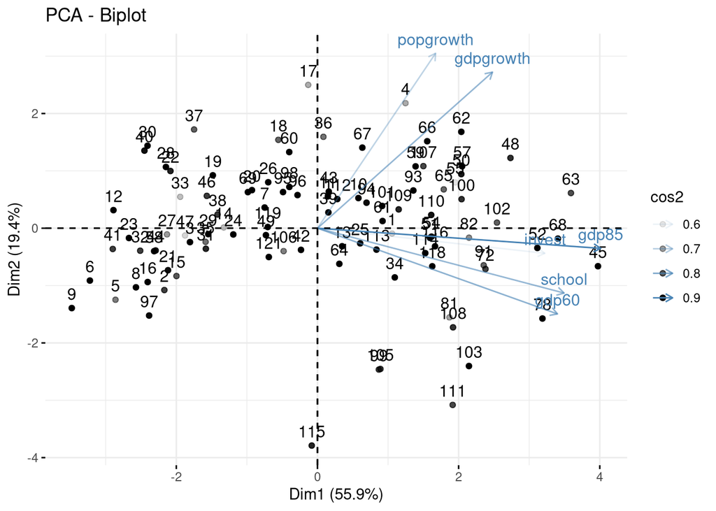

```r
fviz_pca(imputed.pca.noecd, alpha.ind = "cos2", alpha.var = "cos2")
```

Видим, что здесь в первую компоненту положительно вкладываются все старые признаки.